# A/B Testing for a promotion compaign

### -------------- Author: Thu Nguyen ---------------------

## Probem Descriptions:

Data shows the results of a experiment for a promotion campaign. The test was conducted on two groups:

- Group A: the control group which was not subjected to the designed promotion.
- Group B: the treatment group which was subjected to the designed promotion.
- Each group has 1000 customers.
- Each row contains the revenue generated by each customer before and after the compaign.

Target questions:

1. Evaluate the revenue impact of the promotion.
1. "Different customers may have reacted differently to the compaign". Discuss on this statement.

```python
### Import libraries
import pandas as pd
import numpy as np
from datetime import datetime

import matplotlib.pyplot as plt
%matplotlib inline
import seaborn as sns

import plotly.graph_objects as go
import plotly.express as px
```

## 1. About the data

```python
# import data
df = pd.read_csv(r'A_B_testing_1.csv')

##check are there any null or nan data inside dataframe
print ('Check null data in df:\n', df.isnull().sum(),'\n')

## check what is inside column "Period"
print('Period: ',df['Period'].unique(),'\n')

## check data shape
print('df shape: ', df.shape,'\n')

### check column names
print('df columns: ', df.columns.to_list(),'\n')

## print out 3 first rows of dataframe
print('The data looks like:\n', df.head(),'\n')

## data sample distribition
print('Data points per each group:')
df.groupby(['Test_Group', 'Period']).count()
```

```
Check null data in df:
 Customer_Id    0
Test_Group     0
Period         0
Revenue        0
dtype: int64

Period:  ['After Promotion' 'Before Promotion']

df shape:  (4000, 4)

df columns:  ['Customer_Id', 'Test_Group', 'Period', 'Revenue']

The data looks like:
    Customer_Id Test_Group            Period      Revenue
0         1368          A   After Promotion  1349.637961
1         2394          B  Before Promotion  1342.115507
2         2165          B  Before Promotion  1341.406143
3         2651          B  Before Promotion  1334.247420
4         1927          A  Before Promotion  1346.962780

Data points per each group:
```

| Test_Group | Period | Customer_Id | Revenue |
| --- | --- | --- | --- |
| A | After Promotion | 1000 | 1000 |
|  | Before Promotion | 1000 | 1000 |
| B | After Promotion | 1000 | 1000 |
|  | Before Promotion | 1000 | 1000 |

## Q1. Evaluate the revenue impact of the promotion.

- First, I create a new column to categoritise group A & B into sub groups: before & after the promotion

```python
df['sub_groups'] = df['Test_Group'].str.cat(df.Period, sep='-')
df.head(3)
```

|  | Customer_Id | Test_Group | Period | Revenue | sub_groups |
| --- | --- | --- | --- | --- | --- |
| 0 | 1368 | A | After Promotion | 1349.637961 | A-After Promotion |
| 1 | 2394 | B | Before Promotion | 1342.115507 | B-Before Promotion |
| 2 | 2165 | B | Before Promotion | 1341.406143 | B-Before Promotion |

- Next, I sort out data for group A and B seperately. Then, I calculate the revenue change by subtracting the revenue after promotion to revenue before promotion

```python
df_A = df[['Customer_Id','Revenue','sub_groups']].loc[df['Test_Group']=='A']
df_A = pd.pivot_table(df_A, values='Revenue', index=['Customer_Id'], columns=['sub_groups']).reset_index()
df_A['Change']=df_A['A-After Promotion']-df_A['A-Before Promotion']
print('Data for test group A:\n', df_A.head(3))


df_B = df[['Customer_Id','Revenue','sub_groups']].loc[df['Test_Group']=='B']
df_B = pd.pivot_table(df_B, values='Revenue', index=['Customer_Id'], columns=['sub_groups']).reset_index()
df_B['Change']=df_B['B-After Promotion']-df_B['B-Before Promotion']
print('Data for test group B:\n',df_B.head(3))
```

```
Data for test group A:
 sub_groups  Customer_Id  A-After Promotion  A-Before Promotion     Change
0                  1000        1335.042013         1339.395244  -4.353231
1                  1001        1334.600450         1342.698225  -8.097775
2                  1002        1344.820198         1360.587083 -15.766885
Data for test group B:
 sub_groups  Customer_Id  B-After Promotion  B-Before Promotion     Change
0                  2000        1354.938800         1339.883963  15.054837
1                  2001        1372.941736         1347.369379  25.572357
2                  2002        1358.509432         1339.584108  18.925324
```

- PLot Revenue vs Sub Groups

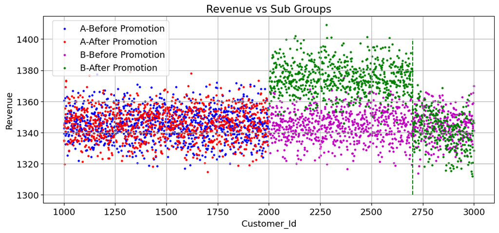

```python
#List sub groups:
sub_groups=['A-Before Promotion','A-After Promotion', 'B-Before Promotion', 'B-After Promotion']

# Plot revenue of all customers in both groups A and B, and both before intervention and after intervention
plt.rc('font', size=13)
fig = plt.figure(figsize=(12, 5))
plt.scatter(df_A['Customer_Id'], df_A['A-Before Promotion'],c='b',s=5)
plt.scatter(df_A['Customer_Id'], df_A['A-After Promotion'],c='r',s=5)
plt.scatter(df_B['Customer_Id'], df_B['B-Before Promotion'],c='m',s=5)
plt.scatter(df_B['Customer_Id'], df_B['B-After Promotion'],c='g',s=5)

plt.plot([2700, 2700], [1300, 1400], c='g', ls='--')
plt.grid()
plt.legend(sub_groups,bbox_to_anchor=(0.01, 1.0), loc='upper left')
plt.xlabel('Customer_Id')
plt.ylabel('Revenue')
plt.title('Revenue vs Sub Groups')

# plt.savefig(r"Revenue_vs_SubGroups.png", bbox_inches='tight', dpi=300)
```

#### Remark 1

```python
# Create statistical summary of all customers's revenue in different sub groups:
statis_sum_A = df_A[['A-Before Promotion','A-After Promotion']].describe()
statis_sum_B = df_B[['B-Before Promotion','B-After Promotion']].describe()
statistic_summary =pd.concat([statis_sum_A,statis_sum_B], axis=1)
statistic_summary
```

| sub_groups | A-Before Promotion | A-After Promotion | B-Before Promotion | B-After Promotion |
| --- | --- | --- | --- | --- |
| count | 1000.000000 | 1000.000000 | 1000.000000 | 1000.000000 |
| mean | 1345.161279 | 1345.424653 | 1344.484063 | 1364.723208 |
| std | 9.916950 | 10.096742 | 9.657143 | 18.829592 |
| min | 1316.902253 | 1314.521391 | 1313.709118 | 1311.952046 |
| 25% | 1338.716758 | 1338.467770 | 1338.255559 | 1351.253077 |
| 50% | 1345.092097 | 1345.548524 | 1344.598418 | 1369.651078 |
| 75% | 1351.646019 | 1352.534503 | 1351.190789 | 1378.512438 |
| max | 1377.410399 | 1378.903708 | 1375.221042 | 1409.210946 |

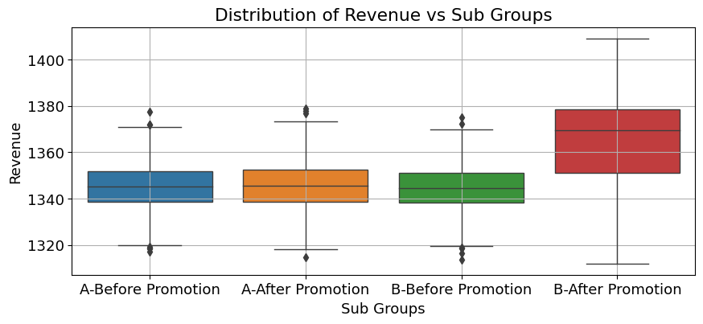

```python
### Box plot to show the ditribution of revenue values within each sub-group
plt.figure(figsize=(10,4))
ax2 = sns.boxplot(x="sub_groups", y='Revenue',order=sub_groups ,data=df, linewidth=1)
plt.xlabel("Sub Groups")
plt.ylabel("Revenue")
plt.grid()
plt.title('Distribution of Revenue vs Sub Groups')
# plt.savefig(r"Revenue_vs_SubGroups_Boxplot.png", bbox_inches='tight', dpi=300)
```

#### Remark 2

- According to the statistic summary table and the boxplot above, we can see that the distribution of the revenue of both groups A and B before Promotion are similar. The mean, min, max, 50th percentile of group A before Promotion are 1345.16, 1316.9, 1377.4, 1345 dollars, respectively. These values of group B before Promotion are 1344.48, 1313.7, 1375.2, 1344.6 dollars, respectively.
- After Promotion, these values of group A are nearly the same as before Promotion. However, for the group B, the mean, max increased to 1364.7, 1409.2 dollars, respectively. The values of 25th, 50th and 75th quartiles also increased significantly to 1351.2, 1369.6 and 1378.5 dollars, respectively.
- For further analysis, next step, I will analyse the revenue changes of group A and B (the column "Change" in df_A and df_B).

### Analyses revenue change using density distribution and box plots

```
Median value of revenue change in group A:  0.45139549999987594
Mean value of revenue change in group A:  0.26337387999999534
Median value of revenue change in group A:  23.518848499999876
Mean value of revenue change in group A:  20.239145549000032
```

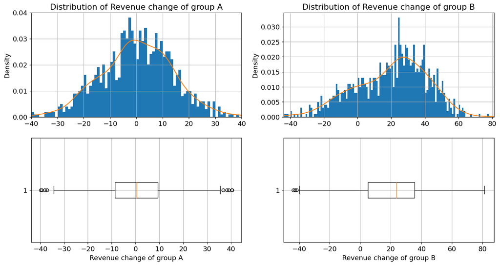

```python
print('Median value of revenue change in group A: ', df_A['Change'].median())
print('Mean value of revenue change in group A: ', df_A['Change'].mean())
print('Median value of revenue change in group A: ', df_B['Change'].median())
print('Mean value of revenue change in group A: ', df_B['Change'].mean())

# Plot Distribution of Revenue change of group A
plt.rc('font', size=13)
fig = plt.figure(figsize=(16, 8))
plt.subplot(2,2,1)

min_revenueA = int(round(min(df_A['Change']),0))
max_revenueA = int(round(max(df_A['Change']),0))
ax = df_A['Change'].plot.hist(density=True, xlim=[min_revenueA,max_revenueA],
                                            bins=range(min_revenueA,max_revenueA))
df_A['Change'].plot.density(ax=ax)

plt.grid()
plt.title('Distribution of Revenue change of group A')


# Box plot to show the ditribution of revenue change within group A
plt.subplot(2,2,3)
plt.boxplot(df_A['Change'], vert=False)
plt.xlabel("Revenue change of group A")
plt.grid()

# Plot Distribution of Revenue change of group B
plt.subplot(2,2,2)

min_revenueB = int(round(min(df_B['Change']),0))
max_revenueB = int(round(max(df_B['Change']),0))
ax = df_B['Change'].plot.hist(density=True, xlim=[min_revenueB,max_revenueB],
                                            bins=range(min_revenueB,max_revenueB))
df_B['Change'].plot.density(ax=ax)

plt.grid()
plt.title('Distribution of Revenue change of group B')

# Box plot to show the ditribution of revenue change within group B
plt.subplot(2,2,4)
plt.boxplot(df_B['Change'], vert=False)
plt.xlabel("Revenue change of group B")
plt.grid()

# plt.savefig(r"Revenue_Density.png", bbox_inches='tight', dpi=300)
```

#### Remark 3

From figure above, we can have following conclusions:

1. Revenue change of Group A: Nearly Normal distribution.
   - The density curve is nearly symmetric to the vertical line at revenue = 0
   - Both left and right tails are reach to +40 and -40 dollars.
1. Revenue change of Group B: slightly Left-Skewed distribution:
   - The density curve is not symmetric and is shifted to the right
   - The median value of the revenue change is 23.5 dollars, the mode value of revenue change is around 28 dollars.
   - The right tail reach to +80 dollars meanwhile the left tail is still -40 dollars.
   - It means that not all players within group B react the same with the intervention. Most of them react very positively to the intervention, leading to the shift of the density curve. However, there is small number of players do not react positively with the intervention, leading to the Left-Skewed distribution. This question will be investigated more carefully in the question Q2.

### Hypotheses Test

To strenthen the conclusions above, I will further evaluate the revenue impact of the promotion by conducting Hypotheses Tests:

- The **Null Hypotheses (H0)**: Revenue after promotion - Revenue before promotion <= 0
- The **Alternative Hypotheses (H1)**: Revenue after promotion - Revenue before promotion > 0

To test the Null Hypotheses, I will simulate (bootstrap) sample data set for both groups A & B, and compute the mean value of revenue change rate for those samples:

- Generate 10000 samples, use the sample size is 25% size of original data of each group
- Calculate mean value of revenue change rate for those samples. Here, the revenue change rate = (Revenue change) / (Revenue before promotion)
- Calculate p-value for null hypothesis for both group A & B

```python
### first, add column "Change%" to calculate revenue change rate = (Revenue change) / (Revenue before promotion)
df_A['Change%'] = df_A['Change']/df_A['A-Before Promotion']
df_B['Change%'] = df_B['Change']/df_B['B-Before Promotion']

### second, sampling and calculate mean value of revenue change rate for those samples
Revenue_change_rates_A = []
Revenue_change_rates_B = []

for i in range(10000):
    df_A_sample = df_A.sample(frac=0.25, replace=False)
    Revenue_change_rates_A.append(df_A_sample['Change%'].mean())

    df_B_sample = df_B.sample(frac=0.25, replace=False)
    Revenue_change_rates_B.append(df_B_sample['Change%'].mean())

df_Revenue_change_rates_A = pd.DataFrame(Revenue_change_rates_A, columns=['Change%'])
df_Revenue_change_rates_B = pd.DataFrame(Revenue_change_rates_B, columns=['Change%'])
```

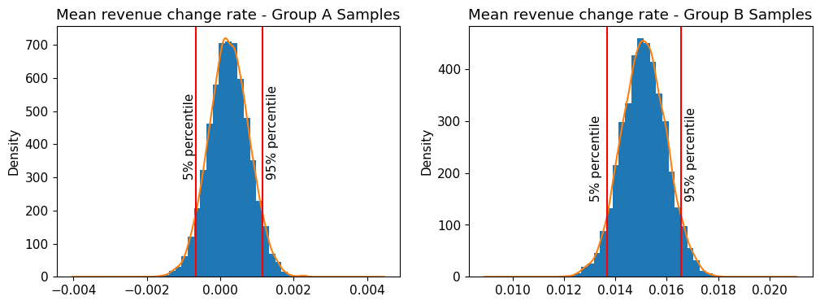

```python
#### Third, plot distribution of these mean value of revenue change rates for each group
plt.figure(figsize=(12,4))
plt.rc('font', size=11)

#### for 1000 samples of group A
plt.subplot(1,2,1)
low, high = np.percentile(df_Revenue_change_rates_A['Change%'], 5.0), np.percentile(df_Revenue_change_rates_A['Change%'], 95.0)

ax = df_Revenue_change_rates_A['Change%'].hist(density=True, bins=25)
df_Revenue_change_rates_A['Change%'].plot.density(ax=ax)

plt.axvline(x= low, color= 'r')
plt.text(1.5*low, 300, '5% percentile', rotation='vertical')

plt.axvline(x= high, color= 'r')
plt.text(1.1*high, 300, '95% percentile', rotation='vertical')
plt.title('Mean revenue change rate - Group A Samples')

#### for 1000 samples of group B
plt.subplot(1,2,2)
low, high = np.percentile(df_Revenue_change_rates_B['Change%'], 5.0), np.percentile(df_Revenue_change_rates_B['Change%'], 95.0)

ax = df_Revenue_change_rates_B['Change%'].hist(density=True, bins=25)
df_Revenue_change_rates_B['Change%'].plot.density(ax=ax)

plt.axvline(x= low, color= 'r')
plt.text(0.95*low, 150, '5% percentile', rotation='vertical')
plt.axvline(x= high, color= 'r')
plt.text(1.01*high, 150, '95% percentile', rotation='vertical')
plt.title('Mean revenue change rate - Group B Samples')
```

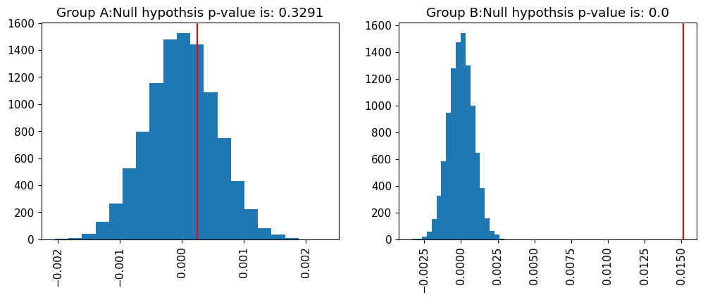

```python
### Finally, plot normal distribution of null hypothesis and calculate p-value for each group
def normal_distribution_null_hypothesis(df_Revenue_change_rates_A, group_name):
    null_vals= np.random.normal(0, df_Revenue_change_rates_A['Change%'].std(), df_Revenue_change_rates_A['Change%'].size)
    plt.hist(null_vals, bins=20)
    plt.axvline(x= df_Revenue_change_rates_A['Change%'].mean(), color= 'r')
    plt.xticks(rotation=90)
    title = group_name+":Null hypothsis p-value is: {}".format((null_vals > df_Revenue_change_rates_A['Change%'].mean()).mean())
    plt.title(title)


plt.figure(figsize=(12,4))
plt.rc('font', size=11)

#### null hypothesis for group A
plt.subplot(1,2,1)
normal_distribution_null_hypothesis(df_Revenue_change_rates_A, 'Group A')
#### null hypothesis for group B
plt.subplot(1,2,2)
normal_distribution_null_hypothesis(df_Revenue_change_rates_B, 'Group B')
```

## Q2. Different players may have reacted differently to the intervention. Discuss on this statement.

- First, by combining the remarks from the density plot of revenue change in the previous section with the below scatter plot (Fig.1), we can have a general observation that within group B, different players do react differently to the intervention. But how is difference?
- As shown in Fig.1: Revenue Change Vs PlayerId, the customer group with ID from 2000 to 2700 seems to have more activities, that leads to the revenue of this sub group increased after promotion. By contrast, the revenue of the customer group with ID from 2700 to 3000 remains unchanged, even decreases.
- The distribution of scatters also suggest a potential Clustering such as KMeans-Clustering to group the players into different groups. However, it is noted that the x-axis of this plot is the player ID which generally (in practice) does not have real meaning related to player's personalities. Therefore, clustering based on PlayerId will lead to some missleading intepretations.
- On the other hand, as shown in Fig.2: Revenue Change Vs Old Revenue, we can see a potential relation that **the Revenue Change decreases as the Revenue before change increase**. This may suggest some regression analyses.

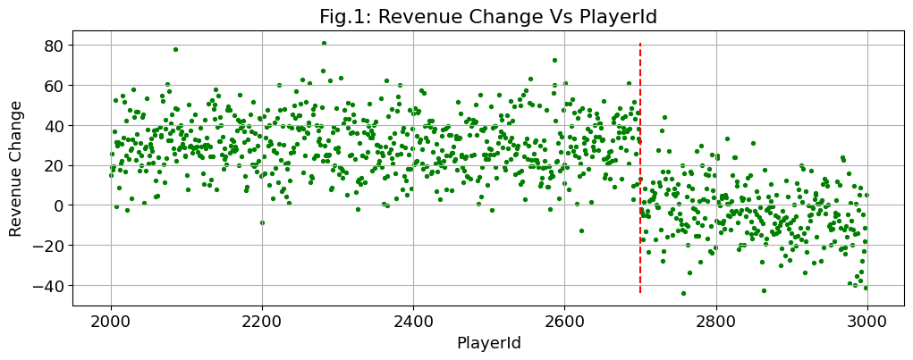

```python
plt.rc('font', size=13)
fig = plt.figure(figsize=(12, 4))
plt.scatter(df_B['Customer_Id'], df_B['Change'],c='g',s=8)
plt.plot([2700, 2700], [df_B['Change'].min(), df_B['Change'].max()], c='r', ls='--')
plt.grid()
plt.xlabel('PlayerId')
plt.ylabel('Revenue Change')
plt.title('Fig.1: Revenue Change Vs PlayerId')
# plt.savefig(r"Bonus_question_Revenue_vs_PlayerID.png", bbox_inches='tight', dpi=300)
```

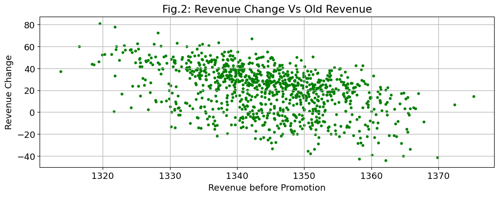

```python
plt.rc('font', size=13)
fig = plt.figure(figsize=(12, 4))
plt.scatter(df_B['B-Before Promotion'], df_B['Change'],c='g',s=10)
plt.grid()
plt.xlabel('Revenue before Promotion')
plt.ylabel('Revenue Change')
plt.title('Fig.2: Revenue Change Vs Old Revenue')

# plt.savefig(r"Bonus_question_Revenue_Change_vs_Old_Revenue.png", bbox_inches='tight', dpi=300)
```

- To prove the potential relation between the Revenue Change and the Revenue Before Change, I calculate the correlation score between them. As we can see, the correlation score is -0.45 suggesting a significant contra - variant relation.

```python
# Calculate correllation score between Revenue before change of group B and the change
corr_matrix = df_B[['B-Before Promotion','Change']].corr()
corr_matrix["Change"].sort_values(ascending=False)
```

```
sub_groups
Change                1.000000
B-Before Promotion   -0.453005
Name: Change, dtype: float64
```

- Next step, I will try to quickly build a simple linear regression model to find out a representable relation between two parameters.

```python
# remove PlayerId and B_After Change since it will not be used for building model.
# The PlayerId normally is the ID and does not has real personal meaning
# The B_After cannot be kept since 'B_After' is dependent to 'B-Before Change' and 'Change'

df_B = df_B[['B-Before Promotion','Change']]

# Split train set and test set:
from sklearn.model_selection import train_test_split
df_train, df_test = train_test_split(df_B, test_size=0.2, random_state=42)
X_train = df_train['B-Before Promotion']
y_train = df_train['Change']

X_test = df_test['B-Before Promotion']
y_test = df_test['Change']

# Scale data using StandardScaler
from sklearn.preprocessing import StandardScaler
autoscaler = StandardScaler()
X_2Darray = X_train.values.reshape(-1,1)
X_train_scaled = autoscaler.fit_transform(X_2Darray)

### Linear regression
from sklearn.linear_model import LinearRegression
from sklearn.model_selection import cross_val_score

lin_reg = LinearRegression()

### Use K-fold cross validation method with 5 folds
scores = cross_val_score(lin_reg, X_train_scaled, y_train,scoring="neg_mean_squared_error", cv=5)
lin_reg_rmse_scores = np.sqrt(-scores)
print(lin_reg_rmse_scores.mean())

lin_reg.fit(X_train_scaled, y_train)
print('Model coefficients: ', lin_reg.coef_)
print('Model intercept: ', lin_reg.intercept_)
```

```
18.747719351314167
Model coefficients:  [-9.87338314]
Model intercept:  20.324819142500026
```

```python
## Quickly evaluate model although building this model is not main purpose of this exercise.
from sklearn.metrics import mean_squared_error

X_test_2Darray = X_test.values.reshape(-1,1)
X_test_scaled = autoscaler.fit_transform(X_test_2Darray)

y_predict = lin_reg.predict(X_test_scaled)

lin_mse = mean_squared_error(y_test, y_predict)
lin_rmse = np.sqrt(lin_mse)
lin_rmse
```

```
19.281448891310543
```

- Now, we can plot Revenue Change vs Old Revenue again with Linear Regression Line

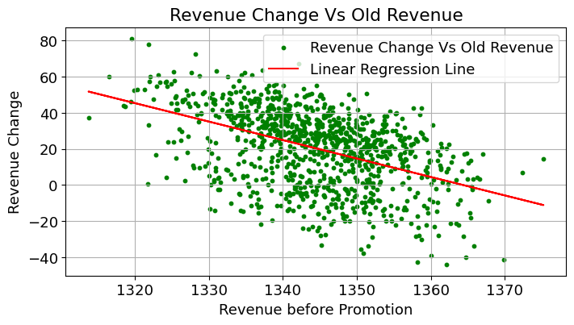

```python
X_all_2Darray = df_B['B-Before Promotion'].values.reshape(-1,1)
X_all_scaled = autoscaler.fit_transform(X_all_2Darray)
y_predict_all = lin_reg.predict(X_all_scaled)

plt.rc('font', size=13)
fig = plt.figure(figsize=(8, 4))
plt.scatter(df_B['B-Before Promotion'], df_B['Change'],c='g',s=10)
plt.plot(df_B['B-Before Promotion'], y_predict_all, c='r', ls='-')

plt.grid()
plt.legend(['Revenue Change Vs Old Revenue','Linear Regression Line'])
plt.xlabel('Revenue before Promotion')
plt.ylabel('Revenue Change')
plt.title('Revenue Change Vs Old Revenue')
# plt.savefig(r"Bonus_question_Revenue_Change_vs_Old_Revenue_regression.png", bbox_inches='tight', dpi=300)
```

- In conclusion, majority of players in group B react quite positively with the intervention.
- There are a small number of players who spent less when subjected to the intervention.
- There is a contra - variant relationship between the Revenue before intervention and the Revenue change due to the intervention. It means that the intervention seems work better for the players who used to spend less. For players who used to generate good revenues, there are certain probabilities that they react negatively to the intervention or they might not react as well as the remainders.

**------------------------------------ THANK YOU VERY MUCH FOR READING MY ANALYSIS ---------------------------------------**